# Adversarial Search: Playing Connect 4

Student Name: Ethan Chou

I have used the following AI tools: Gemini, OpenAi

I understand that my submission needs to be my own work: EC

## Instructions

Total Points: Undegraduates 100, graduate students 110

Complete this notebook and submit it. The notebook needs to be a complete project report with your implementation, documentation including a short discussion of how your implementation works and your design choices, and experimental results (e.g., tables and charts with simulation results) with a short discussion of what they mean. Use the provided notebook cells and insert additional code and markdown cells as needed.

## Introduction

You will implement different versions of agents that play Connect 4:

> "Connect 4 is a two-player connection board game, in which the players choose a color and then take turns dropping colored discs into a seven-column, six-row vertically suspended grid. The pieces fall straight down, occupying the lowest available space within the column. The objective of the game is to be the first to form a horizontal, vertical, or diagonal line of four of one's own discs." (see [Connect Four on Wikipedia](https://en.wikipedia.org/wiki/Connect_Four))

Note that [Connect-4 has been solved](https://en.wikipedia.org/wiki/Connect_Four#Mathematical_solution) in 1988. A connect-4 solver with a discussion of how to solve different parts of the problem can be found here: https://connect4.gamesolver.org/en/

## Task 1: Defining the Search Problem [10 point]

Define the components of the search problem:

- Initial state
- Actions
- Transition model (result function)
- Goal state (terminal state and utility)

Describe each component and then implement it as a function that can be used by search algorithms.

**Initial State:** The initial state of Connect 4 is an empty board setup as a 6 X 7 array. The array is either filled with 0, 1, or -1, with 0 representing empty squares and 1/-1 representing the two players

**Actions** The actions are dropping a disc into a column that is not full

**Transition Model** The transition model takes the current state of the board and the action, and results in the current board plus the location of the piece that is added to that board. When a player drops a disc into a column, it will go to the lowest available row in that column. If the column is full, the player must choose a different column. (result function): s' = result(a,s)

**Goal State** The goal state is when either player gorms a horizontal, vertical, or diagonal line of 4 of their own colored disc, or a tie if no player is able to form a horizontal, vertical, or diagonal line of 4 of their own disc. A win for player 1 has a utility of 1, a win for player 2 has a utility of -1, and a draw has a utility of 0.

How big is the state space? Give an estimate and explain it.

The state space of the board is taking the possible statuses of each space, which is 3 (both players + empty), and raising it to the power of the size of the board, which is 42 ( 6 x 7), so the estimate for the state space is $3^{42}$

How big is the game tree that minimax search will go through? Give an estimate and explain it.

The size of the game tree that minimax search will go through is the number of possible moves that can be made at each row of the board from bottom to top. Each row has 7 possible moves, so the game tree has a branching factor of 7, and the depth of the game tree is the size of the board, which is 42, so the size of the game tree is $7^{42}$. This is much larger than the state space

## Task 2: Game Environment and Random Agent [25 point]

Use a numpy character array as the board.

```python
import numpy as np

def empty_board(shape=(6, 7)):
    return np.full(shape=shape, fill_value=0)

print(empty_board())
```

```
[[0 0 0 0 0 0 0]
 [0 0 0 0 0 0 0]
 [0 0 0 0 0 0 0]
 [0 0 0 0 0 0 0]
 [0 0 0 0 0 0 0]
 [0 0 0 0 0 0 0]]
```

The standard board is $6 \times 7$ but you can use smaller boards to test your code. Instead of colors (red and yellow), I use 1 and -1 to represent the players. Make sure that your agent functions all have the from: `agent_type(board, player = 1)`, where board is the current board position (in the format above) and player is the player whose next move it is and who the agent should play (as 1 and -1).

[figure not shown]

```python
# Visualization code by Randolph Rankin

import matplotlib.pyplot as plt

def visualize(board):
    plt.axes()
    rectangle=plt.Rectangle((-0.5,len(board)*-1+0.5),len(board[0]),len(board),fc='blue')
    circles=[]
    for i,row in enumerate(board):
        for j,val in enumerate(row):
            color='white' if val==0 else 'red' if val==1 else 'yellow'
            circles.append(plt.Circle((j,i*-1),0.4,fc=color))

    plt.gca().add_patch(rectangle)
    for circle in circles:
        plt.gca().add_patch(circle)

    plt.axis('scaled')
    plt.show()

board = [[0, 0, 0, 0, 0, 0, 0],
         [0, 0, 0, 0, 0, 0, 0],
         [0, 0, 0, 0, 0, 0, 0],
         [0, 0, 0, 1, 0, 0, 0],
         [0, 0, 0, 1, 0, 0, 0],
         [0,-1,-1, 1,-1, 0, 0]]
visualize(board)
```

Implement helper functions for:

- A check for available actions in each state `actions(state)`.
- The transition model `result(state, player, action)`.
- Check for terminal states `terminal(state)`.
- The utility function `utility(s, player)`.

Some functions have the player in there so your agent will be able to play red or yellow. Make sure that all these functions work with boards of different sizes (number of columns and rows).

```python
# Your code/ answer goes here.
import numpy as np
from scipy.signal import convolve2d

def actions(state):
    return [col for col in range(len(state[0])) if state[0][col] == 0]

available_actions = actions(board)
print(f"Available actions: {available_actions}")

def result(state, player, action):
    # Player is 1 or -1
    # Create a copy of the board
    new_board = np.copy(state)

    # Find the first non-empty row or the bottom row
    for i in range(len(state)):
        if state[i][action] != 0:
            # Place the piece in the row above the first non-empty row
            new_board[i-1][action] = player
            return new_board
    new_board[len(state)-1][action] = player
    return new_board



def terminal(state):
    state = np.array(state)

    # Define kernels for detecting winning patterns
    horizontal_kernel = np.array([[1, 1, 1, 1]])
    vertical_kernel = np.transpose(horizontal_kernel)
    diag1_kernel = np.eye(4, dtype=np.uint8)
    diag2_kernel = np.fliplr(diag1_kernel)
    detection_kernels = [horizontal_kernel, vertical_kernel, diag1_kernel, diag2_kernel]

    # Check for a win for each player
    for player in [1, -1]:
        for kernel in detection_kernels:
            if (convolve2d(state == player, kernel, mode="valid") == 4).any():
                return player

    # Check if the board is full (draw)
    if np.all(state != 0):
        return 0  # Draw

    # No winner and the board is not full
    return None


terminal_state = terminal(board)
print(f"Terminal state: {terminal_state}")

def utility(state, player):
    if terminal(state) == player:
        return 1
    elif terminal(state) == -player:
        return -1
    else:
        return 0

utility_value = utility(board, 1)
print(f"Utility value: {utility_value}")
```

```
Available actions: [0, 1, 2, 3, 4, 5, 6]
Terminal state: None
Utility value: 0
```

Implement an agent that plays randomly. Make sure the agent function receives as the percept the board and returns a valid action. Use an agent function definition with the following signature (arguments):

`def random_player(board, player = 1): ...`

The argument `player` is used for agents that do not store what color they are playing. The value passed on by the environment should be 1 ot -1 for player red and yellow, respectively. See [Experiments section for tic-tac-toe](https://nbviewer.org/github/mhahsler/CS7320-AI/blob/master/Games/tictactoe_and_or_tree_search.ipynb#Experiments) for an example.

```python
# Your code/ answer goes here.
def random_player(board, player = 1):
    available_actions = actions(board)
    if not available_actions:
        return None
    return np.random.choice(available_actions)
```

Let two random agents play against each other 1000 times. Look at the [Experiments section for tic-tac-toe](https://nbviewer.org/github/mhahsler/CS7320-AI/blob/master/Games/tictactoe_and_or_tree_search.ipynb#Experiments) to see how the environment uses the agent functions to play against each other.

How often does each player win? Is the result expected?

```python
# Your code/ answer goes here.

player1_wins = 0
player2_wins = 0
draws = 0

for i in range(1000):
    board = empty_board()
    current_player = 1
    while True:
        if current_player == 1:
            action = random_player(board, current_player)
            board = result(board, current_player, action)
        else:
            action = random_player(board, current_player)
            board = result(board, current_player, action)
        goal = terminal(board)
        if goal is not None:
            break
        board = result(board, current_player, action)
        current_player = -current_player

    if goal == 1:
        player1_wins += 1
    elif goal == -1:
        player2_wins += 1
    else:
        draws += 1

print(f"Player 1 wins: {player1_wins}")
print(f"Player 2 wins: {player2_wins}")
print(f"Draws: {draws}")
```

```
Player 1 wins: 584
Player 2 wins: 416
Draws: 0
```

## Task 3: Minimax Search with Alpha-Beta Pruning

### Implement the Search [20 points]

Implement minimax search starting from a given board for specifying the player.

**Important Notes:**

- You can use code from the [tic-tac-toe example](https://nbviewer.org/github/mhahsler/CS7320-AI/blob/master/Games/tictactoe_alpha_beta_tree_search.ipynb).
- Make sure that all your agent functions have a signature consistent with the random agent above and that it [uses a class to store state information.](https://nbviewer.org/github/mhahsler/CS7320-AI/blob/master/HOWTOs/store_agent_state_information.ipynb)

This is essential to be able play against agents from other students later.

- The game tree for a $6 \times 7$ board is huge and optimal algorithms need to visit each or a large percentage of all nodes in the tree. You can experiment with smaller boards like a $4 \times 4$ board first.

```python
import math

def max_value(board, player, alpha, beta):
    """player's best move."""
    # If it reaches terminal state, return utility
    terminal_board = terminal(board)
    if terminal_board is not None:
        return utility(board, player), None
    # If not terminal state, return max value of min_value
    v = -math.inf
    move = None
    for action in actions(board):
        value_1, value_2 = min_value(result(board, player, action), player, alpha, beta)
        if value_1 > v:
            v = value_1
            move = action
            alpha = max(alpha, v)
        if v >= beta:
            return v, move
    return v, move

def min_value(board, player, alpha, beta):
    """opponent's best response."""
    # If it reaches terminal state, return utility
    terminal_board = terminal(board)
    if terminal_board is not None:
        return utility(board, player), None
    # If not terminal state, return min value of max_value
    v = math.inf
    move = None
    for action in actions(board):
        value_1, value_2 = max_value(result(board, player, action), (-1)*player, alpha, beta)
        if value_1 < v:
            v = value_1
            move = action
            beta = min(beta, v)
        if v <= alpha:
            return v, move
    return v, move

def alpha_beta_search(board, player):
    """start the search."""
    value, move = max_value(board, player, -np.inf, np.inf)
    return move

class alpha_beta_agent:
    def __init__(self, player):
        self.player = player
        #Store state
        self.state = None

    def play(self, board):
        move = alpha_beta_search(board, self.player)
        self.state = result(board, self.player, move)
        return move
```

Experiment with some manually created boards (at least 5) to check if the agent spots winning opportunities.

```
Board 1 before:
```

[figure not shown]

```
Board 1 after:
```

[figure not shown]

```
Board 2 before:
```

[figure not shown]

```
Board 2 after:
```

[figure not shown]

```
Board 3 before:
```

[figure not shown]

```
Board 3 after:
```

[figure not shown]

```
Board 4 before:
```

[figure not shown]

```
Board 4 after:
```

[figure not shown]

```
Board 5 before:
```

[figure not shown]

```
Board 5 after:
```

[figure not shown]

```python
# Your code/ answer goes here.
board_1 = [[0, 0, 0, 0, 0],
         [0, 0, 0, 0, 0],
         [0, 0, 0, 1, 1],
         [1, -1,-1,-1, 1],
         [1, -1,-1,-1, 1]]

print('Board 1 before:')
visualize(board_1)
agent = alpha_beta_agent(1)
action = agent.play(board_1)
new_board = result(board_1, agent.player, action)
print('Board 1 after:')
visualize(new_board)

print("\n")

board_2 = [[0, 0, 0, 0, 0],
         [0, 1, 1, 0, 0],
         [0, -1, -1, 1, 1],
         [1, -1,-1,-1, 1],
         [1, -1,-1,-1, 1]]

print('Board 2 before:')
visualize(board_2)
agent = alpha_beta_agent(1)
action = agent.play(board_2)
new_board = result(board_2,  agent.player, action)
print('Board 2 after:')
visualize(new_board)

print("\n")

board_3 = [[0, 0, 0, 0, 0],
         [0, -1, -1, 0, 0],
         [0, 1, 1, -1, -1],
         [-1,  1, 1, 1, -1],
         [-1,  1, 1, 1, -1]]

print('Board 3 before:')
visualize(board_3)
agent = alpha_beta_agent(1)
action = agent.play(board_3)
new_board = result(board_3, agent.player, action)
print('Board 3 after:')
visualize(new_board)

print("\n")

board_4 = [[0, 0, 0, 0, 0],
         [0, 1, -1, 0, 0],
         [0, -1, 1, 1, 1],
         [1, -1, 1,-1, 1],
         [1, -1, 1,-1, 1]]

print('Board 4 before:')
visualize(board_4)
agent = alpha_beta_agent(1)
action = agent.play(board_4)
new_board = result(board_4, agent.player, action)
print('Board 4 after:')
visualize(new_board)

print("\n")

board_5 = [[0, 0, 0, 0, 0],
         [0, 1, 1, 0, 0],
         [0, -1, 1, -1, 1],
         [1, -1, 1,-1, -1],
         [1, -1,-1,-1, 1]]

print('Board 5 before:')
visualize(board_5)
agent = alpha_beta_agent(1)
action = agent.play(board_5)
new_board = result(board_5, agent.player, action)
print('Board 5 after:')
visualize(new_board)
```

For the boards where there is a clear winning opportunity, the agent is able to play the correct move. For boards where there is no clear winning opportunity, the agent will play the move that will get it closest to a winning opportunity

How long does it take to make a move? Start with a smaller board with 4 columns and make the board larger by adding columns/rows. Explain why using this algorithm on a standard $6 \times 7$ board takes forever.

```
5 X 4 board before:
```

[figure not shown]

```
Time taken: 0.21169543266296387 seconds
5 X 4 board after:
```

[figure not shown]

```
6 X 4 board before:
```

```
Time taken: 2.244842052459717 seconds
6 X 4 board after:
```

[figure not shown]

```
6 X 5 board before:
```

```
Time taken: 3.7715165615081787 seconds
6 X 5 board after:
```

```
5 X 6 board before:
```

```
Time taken: 31.957617044448853 seconds
5 X 6 board after:
```

[figure not shown]

```python
import time
board_1 = [[0, 0, 0, 0],
         [0, 0, 0, 0],
         [0, 0, 0, 1],
         [1, -1,-1,-1],
         [1, -1,-1,-1]]

print('5 X 4 board before:')
visualize(board_1)
agent = alpha_beta_agent(1)
time_start = time.time()
action = agent.play(board_1)
new_board = result(board_1, agent.player, action)
time_end = time.time()
print(f"Time taken: {time_end - time_start} seconds")
print('5 X 4 board after:')
visualize(new_board)


board_1 = [[0, 0, 0, 0],
         [0, 0, 0, 0],
         [0, 0, 0, 0],
         [0, 0, 0, 1],
         [1, -1,-1,-1],
         [1, -1,-1,-1]]

print('6 X 4 board before:')
visualize(board_1)
agent = alpha_beta_agent(1)
time_start = time.time()
action = agent.play(board_1)
new_board = result(board_1, agent.player, action)
time_end = time.time()
print(f"Time taken: {time_end - time_start} seconds")
print('6 X 4 board after:')
visualize(new_board)

print("\n")

board_1 = [[0, 0, 0, 0, 0],
         [0, 0, 0, 0, 0],
         [0, 0, 0, 0, 0],
         [0, 0, 0, 1, 1],
         [1, -1,-1,-1, 1],
         [1, -1,-1,-1, 1]]

print('6 X 5 board before:')
visualize(board_1)
agent = alpha_beta_agent(1)
time_start = time.time()
action = agent.play(board_1)
new_board = result(board_1, agent.player, action)
time_end = time.time()
print(f"Time taken: {time_end - time_start} seconds")
print('6 X 5 board after:')
visualize(new_board)

print("\n")

board_1 = [[0, 0, 0, 0, 0 ,0],
         [0, 0, 0, 0, 0 ,0],
         [0, 0, 0, -1, 1 ,0],
         [1, -1,-1, 1, 1 ,0],
         [1, -1, 1,-1, -1 ,0]]

print('5 X 6 board before:')
visualize(board_1)
agent = alpha_beta_agent(1)
time_start = time.time()
action = agent.play(board_1)
new_board = result(board_1, agent.player, action)
time_end = time.time()
print(f"Time taken: {time_end - time_start} seconds")
print('5 X 6 board after:')
visualize(new_board)

print("\n")
```

[output not shown]

### Move ordering [5 points]

Starting the search with better moves will increase the efficiency of alpha-beta pruning. Describe and implement a simple move ordering strategy. Make a table that shows how the ordering strategies influence the time it takes to make a move?

I prioritized moves that will either win the game, or prevent the opponent from winning the game.

```python
# Your code/ answer goes here.
# Implement a move ordering strategy that prioritizes the most promising moves
def move_ordering(board, player, moves):
    # Initialize lists for categorizing moves
    winning_moves = []
    blocking_moves = []

    # Check each move
    for move in moves:
        # Simulate the move for the current player
        new_board = result(board, player, move)
        if terminal(new_board) == player:
            winning_moves.append(move)
        elif terminal(result(board, -player, move)) == -player:
            blocking_moves.append(move)

    # Return moves based on priority
    if winning_moves:
        return winning_moves
    if blocking_moves:
        return blocking_moves
    return moves


def max_value_ordering(board, player, alpha, beta):
    """player's best move."""
    # If terminal state, return utility
    terminal_board = terminal(board)
    if terminal_board is not None:
        return utility(board, player), None
    v = -math.inf
    move = None
    # Precompute terminal states and prioritize moves
    moves = actions(board)
    moves = move_ordering(board, player, moves)
    for action in moves:
        value, value_2 = min_value_ordering(result(board, player, action), -player, alpha, beta)
        if value > v:
            v = value
            move = action
            alpha = max(alpha, v)
        if alpha >= beta:
            return v, move
    return v, move

def min_value_ordering(board, player, alpha, beta):
    """opponent's best response."""
    # If terminal state, return utility
    terminal_board = terminal(board)
    if terminal_board is not None:
        return utility(board, player), None
    v = math.inf
    move = None
    # Precompute terminal states and prioritize moves
    moves = actions(board)
    moves = move_ordering(board, player, moves)
    for action in moves:
        value, value_2 = max_value_ordering(result(board, player, action), -player, alpha, beta)
        if value < v:
            v = value
            move = action
            beta = min(beta, v)
        if beta <= alpha:
            return v, move
    return v, move

def alpha_beta_search_ordering(board, player):
    """start the search."""
    value, move = max_value_ordering(board, player, -np.inf, np.inf)
    return move

class alpha_beta_agent_ordering:
    def __init__(self, player):
        self.player = player
        self.state = None
    def play(self, board):
        move = alpha_beta_search_ordering(board, self.player)
        self.state = result(board, self.player, move)
        return move
```

```
5 X 4 board before:
```

[figure not shown]

```
Time taken: 0.24773001670837402 seconds
5 X 4 board after:
```

[figure not shown]

```
6 X 4 board before:
```

```
Time taken: 4.077023983001709 seconds
6 X 4 board after:
```

```
6 X 5 board before:
```

```
Time taken: 0.0009965896606445312 seconds
6 X 5 board after:
```

```
5 X 6 board before:
```

```
Time taken: 5.996216535568237 seconds
5 X 6 board after:
```

```python
import time
board_1 = [[0, 0, 0, 0],
         [0, 0, 0, 0],
         [0, 0, 0, 1],
         [1, -1,-1,-1],
         [1, -1,-1,-1]]

print('5 X 4 board before:')
visualize(board_1)
agent = alpha_beta_agent(1)
time_start = time.time()
action = agent.play(board_1)
new_board = result(board_1, agent.player, action)
time_end = time.time()
print(f"Time taken: {time_end - time_start} seconds")
print('5 X 4 board after:')
visualize(new_board)


board_1 = [[0, 0, 0, 0],
         [0, 0, 0, 0],
         [0, 0, 0, 0],
         [0, 0, 0, 1],
         [1, -1,-1,-1],
         [1, -1,-1,-1]]

print('6 X 4 board before:')
visualize(board_1)
agent_order = alpha_beta_agent_ordering(1)
time_start = time.time()
action = agent_order.play(board_1)
new_board = result(board_1, agent.player, action)
time_end = time.time()
print(f"Time taken: {time_end - time_start} seconds")
print('6 X 4 board after:')
visualize(new_board)

print("\n")

print("\n")

board_1 = [[0, 0, 0, 0, 0],
         [0, 0, 0, 0, 0],
         [0, 0, 0, 0, 0],
         [0, 0, 0, 1, 1],
         [1, -1,-1,-1, 1],
         [1, -1,-1,-1, 1]]

print('6 X 5 board before:')
visualize(board_1)
agent_order = alpha_beta_agent_ordering(1)
time_start = time.time()
action = agent_order.play(board_1)
new_board = result(board_1, agent.player, action)
time_end = time.time()
print(f"Time taken: {time_end - time_start} seconds")
print('6 X 5 board after:')
visualize(new_board)

print("\n")

board_1 = [[0, 0, 0, 0, 0 ,0],
         [0, 0, 0, 0, 0 ,0],
         [0, 0, 0, -1, 1 ,0],
         [1, -1,-1, 1, 1 ,0],
         [1, -1, 1,-1, -1 ,0]]

print('5 X 6 board before:')
visualize(board_1)
agent_order = alpha_beta_agent_ordering(1)
time_start = time.time()
action = agent_order.play(board_1)
new_board = result(board_1, agent.player, action)
time_end = time.time()
print(f"Time taken: {time_end - time_start} seconds")
print('5 X 6 board after:')
visualize(new_board)

print("\n")
```

[output not shown]

[output not shown]

### The first few moves [5 points]

Start with an empty board. This is the worst case scenario for minimax search since it needs solve all possible games that can be played (minus some pruning) before making the decision. What can you do?

In order to resolve the issue of the empty board being the worst case scenario, a cutoff depth can be implemented, which will limit the number of moves that minimax search will search ahead, decreasing runtime. However, it does mean that the agent may end up making less optimal moves if it cuts off before reaching the optimal move.

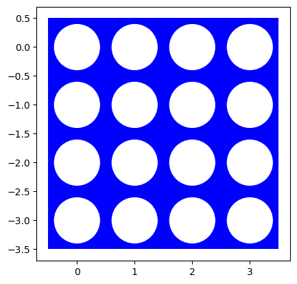

```
Time taken: 10.042486906051636 seconds
```

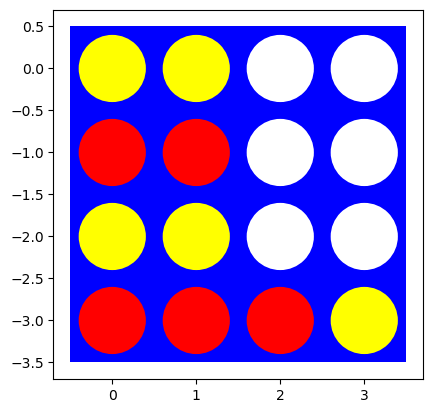

```python
# Your code/ answer goes here.
import time
board = empty_board((4,4))
visualize(board)
player_1 = alpha_beta_agent_ordering(1)
player_2 = alpha_beta_agent_ordering(-1)

start_time = time.time()
for i in range(5):
    # Player 1's turn
    action = player_1.play(board)
    board = result(board, player_1.player, action)
    terminal_board = terminal(board)
    if terminal_board is not None:
        if terminal_board == 1:
            print("Player 1 wins")
        elif terminal_board == -1:
            print("Player 2 wins")
        else:
            print("Draw")
        break
    # Player 2's turn
    action = player_2.play(board)
    board = result(board, player_2.player, action )
    terminal_board = terminal(board)
    if terminal_board is not None:
        if terminal_board == 1:
            print("Player 1 wins")
        elif terminal_board == -1:
            print("Player 2 wins")
        else:
            print("Draw")
        break

end_time = time.time()
print(f"Time taken: {end_time - start_time} seconds")
visualize(board)
```

### Playtime [5 points]

Let the Minimax Search agent play a random agent on a $4 \times 4$ board. Analyze wins, losses and draws.

```python
# Your code/ answer goes here.
import time
player_1_wins = 0
player_2_wins = 0
draws = 0

start_time = time.time()
for i in range(20):  # Number of games to simulate
    board = empty_board((4, 4))  # 4x4 board
    player_1 = alpha_beta_agent_ordering(1)  # Alpha-Beta agent

    while True:
        # Player 1's turn (Alpha-Beta agent)
        action = player_1.play(board)
        board = result(board, player_1.player, action)
        terminal_board = terminal(board)
        if terminal_board is not None:
            if terminal_board == 1:
                player_1_wins += 1
            elif terminal_board == -1:
                player_2_wins += 1
            else:
                draws += 1
            break  # Game ends

        # Player 2's turn (Random agent)
        action = random_player(board, -1)
        if action is None:  # No available moves
            draws += 1
            break
        board = result(board, -1, action)
        terminal_board = terminal(board)
        if terminal_board is not None:
            if terminal_board == 1:
                player_1_wins += 1
            elif terminal_board == -1:
                player_2_wins += 1
            else:
                draws += 1
            break  # Game ends


end_time = time.time()
print(f"Time taken: {end_time - start_time} seconds")
print(f"Player 1 Alpha Beta with Move Ordering wins: {player_1_wins}")
print(f"Player 2 Random wins: {player_2_wins}")
print(f"Draws: {draws}")
```

```
Time taken: 111.42764067649841 seconds
Player 1 Alpha Beta with Move Ordering wins: 13
Player 2 Random wins: 0
Draws: 7
```

After 20 rounds, it is clear that the mini max agent with move ordering performs much better than the random agent, with the mini max agent winning 13 out of 20 games, while the random agent did not win a single game. The draws can be explained by the random agent getting lucky enough to block the mini max agent. Overall, though this shows that the mini max agent with move ordering is much better compared to choosing randomly

## Task 4: Heuristic Alpha-Beta Tree Search

### Heuristic evaluation function [15 points]

Define and implement a heuristic evaluation function. Make sure that the heuristic value stays in the correct range.

```python
import numpy as np

def eval_fun(state, player=1):
    """Heuristic for utility of state. Returns score for a node:
    1. For terminal states it returns the utility.
    2. For non-terminal states, it calculates a weighted linear function using features of the state.
       The features we look at are 3 in a row/col/diagonal where the 4th square is empty.
       We assume that the more of these positions we have, the higher the chance of winning.

    Function Returns: heuristic value, terminal?"""

    # Terminal state?
    u = utility(state, player)
    if u is not None:
        return u, True

    score = 0
    board = np.array(state)
    rows, cols = board.shape

    # Calculate diagonals
    diagonals = []
    for d in range(-rows + 1, cols):  # Positive slope diagonals
        diagonals.append(np.diagonal(board, offset=d))
    for d in range(-rows + 1, cols):  # Negative slope diagonals
        diagonals.append(np.diagonal(np.fliplr(board), offset=d))

    # Normalize score by a factor proportional to the board size
    normalization_factor = (rows * cols) * 0.4

    for a_board in [board, np.transpose(board), diagonals]:
        for row in a_board:
            if len(row) < 4:  # Skip rows that cannot have 4 in a line
                continue
            for i in range(len(row) - 3):  # Sliding window for 4 elements
                window = row[i:i+4]
                if sum(window == player) == 3 and sum(window == 0) == 1:
                    score += 0.4
                if sum(window == -player) == 3 and sum(window == 0) == 1:
                    score -= 0.4

    # Normalize score to stay within [-1, 1]
    score = score / normalization_factor
    score = max(-1, min(1, score))  # Clamp to [-1, 1]

    return score, False
```

### Cutting Off Search [10 points]

Modify your minimax search with alpha-beta pruning to cut off search at a specified depth and use the heuristic evaluation function. Experiment with different cutoff values.

```python
import numpy as np

def max_value_ordering_heuristic(board, player, alpha, beta, depth):
    """player's best move."""
    # Check if terminal state or cut-off depth reached
    terminal_board = terminal(board)
    if terminal_board is not None:
        return utility(board, player), None  # Return terminal utility
    if depth == 0:
        return eval_fun(board, player)[0], None  # Use heuristic value at cut-off

    v = -math.inf
    move = None

    # Precompute and prioritize moves using heuristic evaluation
    moves = actions(board)
    moves = move_ordering(board, player, moves)

    # Perform Alpha-Beta pruning
    for action in moves:
        value, value_2 = min_value_ordering_heuristic(result(board, player, action), -player, alpha, beta, depth - 1)
        if value > v:
            v = value
            move = action
            alpha = max(alpha, v)
        if alpha >= beta:
            return v, move
    return v, move


def min_value_ordering_heuristic(board, player, alpha, beta, depth):
    """opponent's best response."""
    # Check if terminal state or cut-off depth reached
    terminal_board = terminal(board)
    if terminal_board is not None:
        return utility(board, player), None  # Return terminal utility
    if depth == 0:
        return eval_fun(board, player)[0], None  # Use heuristic value at cut-off

    v = math.inf
    move = None

    # Precompute and prioritize moves using heuristic evaluation
    moves = actions(board)
    moves = move_ordering(board, player, moves)

    # Perform Alpha-Beta pruning
    for action in moves:
        value, value_2 = max_value_ordering_heuristic(result(board, player, action), -player, alpha, beta, depth - 1)
        if value < v:
            v = value
            move = action
            beta = min(beta, v)
        if beta <= alpha:
            return v, move
    return v, move


# Alpha-Beta search with cut-off depth
def alpha_beta_search_ordering_heuristic(board, player, max_depth):
    """start the search."""
    value, move = max_value_ordering_heuristic(board, player, -np.inf, np.inf, max_depth)
    return move


# Alpha-Beta agent class with cut-off depth
class alpha_beta_agent_ordering_heuristic:
    def __init__(self, player, max_depth):
        self.player = player
        self.max_depth = max_depth
        self.state = None
        self.first_move = True  # Track whether this player has played their first move

    def play(self, board):
        middle_column = len(board[0]) // 2  # Determine the middle column

        # Force middle column only on an empty board and for the first move
        # Middle column move is the best move according to connect4 experts
        if self.first_move and np.all(board == 0):  # Check if the board is completely empty
            self.first_move = False  # Mark first move as done
            return middle_column  # Force a move in the middle column

        # For other scenarios, use Alpha-Beta search
        self.first_move = False
        move = alpha_beta_search_ordering_heuristic(board, self.player, self.max_depth)
        self.state = result(board, self.player, move)
        return move
```

Experiment with the same manually created boards as above to check if the agent spots wining opportunities.

```
Board 1 before:
```

[figure not shown]

```
Board 1 after:
```

[figure not shown]

```
Board 2 before:
```

[figure not shown]

```
Board 2 after:
```

[figure not shown]

```
Board 3 before:
```

[figure not shown]

```
Board 3 after:
```

[figure not shown]

```
Board 4 before:
```

[figure not shown]

```
Board 4 after:
```

[figure not shown]

```
Board 5 before:
```

[figure not shown]

```
Board 5 after:
```

[figure not shown]

```python
# Your code/ answer goes here.
board_1 = [[0, 0, 0, 0, 0],
         [0, 0, 0, 0, 0],
         [0, 0, 0, 1, 1],
         [1, -1,-1,-1, 1],
         [1, -1,-1,-1, 1]]

print('Board 1 before:')
visualize(board_1)
agent = alpha_beta_agent_ordering_heuristic(1, 50)
action = agent.play(board_1)
new_board = result(board_1, agent.player, action)
print('Board 1 after:')
visualize(new_board)

print("\n")

board_2 = [[0, 0, 0, 0, 0],
         [0, 1, 1, 0, 0],
         [0, -1, -1, 1, 1],
         [1, -1,-1,-1, 1],
         [1, -1,-1,-1, 1]]

print('Board 2 before:')
visualize(board_2)
agent = alpha_beta_agent_ordering_heuristic(1, 50)
action = agent.play(board_2)
new_board = result(board_2, agent.player, action)
print('Board 2 after:')
visualize(new_board)

print("\n")

board_3 = [[0, 0, 0, 0, 0],
         [0, -1, -1, 0, 0],
         [0, 1, 1, -1, -1],
         [-1,  1, 1, 1, -1],
         [-1,  1, 1, 1, -1]]

print('Board 3 before:')
visualize(board_3)
agent = alpha_beta_agent_ordering_heuristic(1, 50)
action = agent.play(board_3)
new_board = result(board_3, agent.player, action)
print('Board 3 after:')
visualize(new_board)

print("\n")

board_4 = [[0, 0, 0, 0, 0],
         [0, 1, -1, 0, 0],
         [0, -1, 1, 1, 1],
         [1, -1, 1,-1, 1],
         [1, -1, 1,-1, 1]]

print('Board 4 before:')
visualize(board_4)
agent = alpha_beta_agent_ordering_heuristic(1, 50)
action = agent.play(board_4)
new_board = result(board_4, agent.player, action)
print('Board 4 after:')
visualize(new_board)

print("\n")

board_5 = [[0, 0, 0, 0, 0],
         [0, 1, 1, 0, 0],
         [0, -1, 1, -1, 1],
         [1, -1, 1,-1, -1],
         [1, -1,-1,-1, 1]]

print('Board 5 before:')
visualize(board_5)
agent = alpha_beta_agent_ordering_heuristic(1, 50)
action = agent.play(board_5)
new_board = result(board_5, agent.player, action)
print('Board 5 after:')
visualize(new_board)
```

The agent is clearly able to spot the winning opportunities in each manually created board, and for the board where there is no winning opportunity, the agent still makes the move that will get it to as close as a winning state for future moves.

How long does it take to make a move? Start with a smaller board with 4 columns and make the board larger by adding columns.

```
6 X 4 board before:
```

```
Time taken: 0.7554192543029785 seconds
6 X 4 board after:
```

```
6 X 5 board before:
```

```
Time taken: 0.001965761184692383 seconds
6 X 5 board after:
```

```
5 X 6 board before:
```

```
Time taken: 0.27814579010009766 seconds
5 X 6 board after:
```

```
5 X 7 board before:
```

[figure not shown]

```
Time taken: 3.687734603881836 seconds
5 X 7 board after:
```

[figure not shown]

```python
# Your code/ answer goes here.
import time

board_1 = [[0, 0, 0, 0],
         [0, 0, 0, 0],
         [0, 0, 0, 0],
         [0, 0, 0, 1],
         [1, -1,-1,-1],
         [1, -1,-1,-1]]

print('6 X 4 board before:')
visualize(board_1)
agent_heuristic = alpha_beta_agent_ordering_heuristic(1, 10)
time_start = time.time()
action = agent_heuristic.play(board_1)
new_board = result(board_1, agent_heuristic.player, action)
time_end = time.time()
print(f"Time taken: {time_end - time_start} seconds")
print('6 X 4 board after:')
visualize(new_board)

print("\n")

print("\n")

board_1 = [[0, 0, 0, 0, 0],
         [0, 0, 0, 0, 0],
         [0, 0, 0, 0, 0],
         [0, 0, 0, 1, 1],
         [1, -1,-1,-1, 1],
         [1, -1,-1,-1, 1]]

print('6 X 5 board before:')
visualize(board_1)
agent_heuristic = alpha_beta_agent_ordering_heuristic(1, 10)
time_start = time.time()
action = agent_heuristic.play(board_1)
new_board = result(board_1, agent_heuristic.player, action)
time_end = time.time()
print(f"Time taken: {time_end - time_start} seconds")
print('6 X 5 board after:')
visualize(new_board)

print("\n")

board_1 = [[0, 0, 0, 0, 0 ,0],
         [0, 0, 0, 0, 0 ,0],
         [0, 0, 0, -1, 1 ,0],
         [1, -1,-1, 1, 1 ,0],
         [1, -1, 1,-1, -1 ,0]]

print('5 X 6 board before:')
visualize(board_1)
agent_heuristic = alpha_beta_agent_ordering_heuristic(1, 10)
time_start = time.time()
action = agent_heuristic.play(board_1)
new_board = result(board_1, agent_heuristic.player, action)
time_end = time.time()
print(f"Time taken: {time_end - time_start} seconds")
print('5 X 6 board after:')
visualize(new_board)

print("\n")

board_1 = [[0, 0, 0, 0, 0 ,0 ,0],
         [0, 0, 0, 0, 0 ,0 ,0],
         [0, 0, 0, 1, -1 ,0, 1],
         [1, -1,-1,-1, 1 ,0, -1],
         [1, -1, 1,-1, 1 ,0, 1]]

print('5 X 7 board before:')
visualize(board_1)
agent_heuristic = alpha_beta_agent_ordering_heuristic(1, 10)
time_start = time.time()
action = agent_heuristic.play(board_1)
new_board = result(board_1, agent_heuristic.player, action)
time_end = time.time()
print(f"Time taken: {time_end - time_start} seconds")
print('5 X 7 board after:')
visualize(new_board)

print("\n")
```

[output not shown]

|  | Alpha Beta with Move Ordering and Heuristic runtime | Board Size |  |
| --- | --- | --- | --- |
|  | 0.755 | 6 X 4 |  |
|  | 0.001 | 6 x 5 |  |
|  | 0.27 | 5 x 6 |  |
|  | 3.68 | 5 x 7 |  |

For the 6 x 5 board, I believe that the reason it is so fast is because that board has a clear winning opportunity, so the agent does not need to spend as much time calculating the optimal move to play.

### Playtime [5 points]

Let two heuristic search agents (different cutoff depth, different heuristic evaluation function) compete against each other on a reasonably sized board. Since there is no randomness, you only need to let them play once.

```python
# Your code/ answer goes here.

player_1_wins = 0
player_2_wins = 0
draws = 0
board = empty_board((6, 7))  # 6x7 board
start_time = time.time()
for i in range(1):  # Number of games to simulate

    player_1 = alpha_beta_agent_ordering_heuristic(1, 5)
    player_2 = alpha_beta_agent_ordering_heuristic(-1, 4)
    while True:
        # Player 1's turn (Alpha-Beta agent)
        action = player_1.play(board)
        board = result(board, player_1.player, action)
        terminal_board = terminal(board)
        if terminal_board is not None:
            if terminal_board == 1:
                player_1_wins += 1
            elif terminal_board == -1:
                player_2_wins += 1
            else:
                draws += 1
            break  # Game ends

        # Player 2's turn
        action = player_2.play(board)
        if action is None:  # No available moves
            draws += 1
            break
        board = result(board, player_2.player, action)
        terminal_board = terminal(board)
        if terminal_board is not None:
            if terminal_board == 1:
                player_1_wins += 1
            elif terminal_board == -1:
                player_2_wins += 1
            else:
                draws += 1
            break  # Game ends

visualize(board)
end_time = time.time()
print(f"Time taken: {end_time - start_time} seconds")
print(f"Player 1 wins: {player_1_wins}")
print(f"Player 2 wins: {player_2_wins}")
print(f"Draws: {draws}")

# Your code/ answer goes here.

player_1_wins = 0
player_2_wins = 0
draws = 0
board = empty_board((6, 7))  # 6x7 board
start_time = time.time()
for i in range(1):  # Number of games to simulate

    player_1 = alpha_beta_agent_ordering_heuristic(1, 5)
    player_2 = alpha_beta_agent_ordering_heuristic(-1, 5)
    while True:
        # Player 1's turn (Alpha-Beta agent)
        action = player_1.play(board)
        board = result(board, player_1.player, action)
        terminal_board = terminal(board)
        if terminal_board is not None:
            if terminal_board == 1:
                player_1_wins += 1
            elif terminal_board == -1:
                player_2_wins += 1
            else:
                draws += 1
            break  # Game ends

        # Player 2's turn
        action = player_2.play(board)
        if action is None:  # No available moves
            draws += 1
            break
        board = result(board, player_2.player, action)
        terminal_board = terminal(board)
        if terminal_board is not None:
            if terminal_board == 1:
                player_1_wins += 1
            elif terminal_board == -1:
                player_2_wins += 1
            else:
                draws += 1
            break  # Game ends

visualize(board)
end_time = time.time()
print(f"Time taken: {end_time - start_time} seconds")
print(f"Player 1 wins: {player_1_wins}")
print(f"Player 2 wins: {player_2_wins}")
print(f"Draws: {draws}")

player_1_wins = 0
player_2_wins = 0
draws = 0
board = empty_board((6, 7))  # 6x7 board
start_time = time.time()
for i in range(1):  # Number of games to simulate

    player_1 = alpha_beta_agent_ordering_heuristic(1, 5)
    player_2 = alpha_beta_agent_ordering_heuristic(-1, 6)
    while True:
        # Player 1's turn (Alpha-Beta agent)
        action = player_1.play(board)
        board = result(board, player_1.player, action)
        terminal_board = terminal(board)
        if terminal_board is not None:
            if terminal_board == 1:
                player_1_wins += 1
            elif terminal_board == -1:
                player_2_wins += 1
            else:
                draws += 1
            break  # Game ends

        # Player 2's turn
        action = player_2.play(board)
        if action is None:  # No available moves
            draws += 1
            break
        board = result(board, player_2.player, action)
        terminal_board = terminal(board)
        if terminal_board is not None:
            if terminal_board == 1:
                player_1_wins += 1
            elif terminal_board == -1:
                player_2_wins += 1
            else:
                draws += 1
            break  # Game ends

visualize(board)
end_time = time.time()
print(f"Time taken: {end_time - start_time} seconds")
print(f"Player 1 wins: {player_1_wins}")
print(f"Player 2 wins: {player_2_wins}")
print(f"Draws: {draws}")

player_1_wins = 0
player_2_wins = 0
draws = 0
board = empty_board((6, 7))  # 6x7 board
start_time = time.time()
for i in range(1):  # Number of games to simulate

    player_1 = alpha_beta_agent_ordering_heuristic(1, 10)
    player_2 = alpha_beta_agent_ordering_heuristic(-1, 5)
    while True:
        # Player 1's turn (Alpha-Beta agent)
        action = player_1.play(board)
        board = result(board,  player_1.player, action)
        terminal_board = terminal(board)
        if terminal_board is not None:
            if terminal_board == 1:
                player_1_wins += 1
            elif terminal_board == -1:
                player_2_wins += 1
            else:
                draws += 1
            break  # Game ends

        # Player 2's turn
        action = player_2.play(board)
        if action is None:  # No available moves
            draws += 1
            break
        board = result(board, player_2.player, action)
        terminal_board = terminal(board)
        if terminal_board is not None:
            if terminal_board == 1:
                player_1_wins += 1
            elif terminal_board == -1:
                player_2_wins += 1
            else:
                draws += 1
            break  # Game ends

visualize(board)
end_time = time.time()
print(f"Time taken: {end_time - start_time} seconds")
print(f"Player 1 wins: {player_1_wins}")
print(f"Player 2 wins: {player_2_wins}")
print(f"Draws: {draws}")
```

[output not shown]

```
Time taken: 1.6833693981170654 seconds
Player 1 wins: 0
Player 2 wins: 0
Draws: 1
```

```
Time taken: 2.2920281887054443 seconds
Player 1 wins: 0
Player 2 wins: 0
Draws: 1
```

```
Time taken: 4.219137668609619 seconds
Player 1 wins: 0
Player 2 wins: 0
Draws: 1
```

```
Time taken: 40.50089621543884 seconds
Player 1 wins: 0
Player 2 wins: 0
Draws: 1
```